# Nitrogen dynamics for MS draft: Spatiotemporal variation in mountain stream metabolism and nitrogen cycling across contrasting flow regimes

Kelly Loria

2025-02-27

#### Calculate nitrogen demand:

```r
# Constants
ra <- 0.5  # Autotrophic respiration coefficient (Hall & Tank 2003)
C_Nauto <- 16  # Autotrophic C:N ratio (Stelzer & Lamberti 2001)
C_Nhetero <- 20  # Heterotrophic C:N ratio (Hall & Tank 2003)
HGE <- 0.05  # Heterotrophic Growth Efficiency (Hall & Tank 2003)

# Calculate components of nitrogen demand
covariat_ndemand <- covariat_datq %>%
  group_by(site) %>%
  mutate(
    # Autotrophic respiration (raGPP)
    raGPP = GPP_mean * ra,
    # Autotrophic assimilation of N
    Auto_N_assim = GPP_mean / C_Nauto,
    # Heterotrophic respiration (Rh)
    Rh = ER_mean - raGPP,
    # Heterotrophic assimilation of N
    Hetero_N_assim = (Rh * HGE) / C_Nhetero,
    # Total nitrogen demand
    Ndemand = Auto_N_assim + Hetero_N_assim, # unit should be g N m-2 d-1
    Ndemand = if_else(Ndemand < 0, 0.0001, Ndemand)) %>%
  dplyr::select(site, date, Ndemand)
```

### Quality check on supply calculations:

1. How many missing data points is it and how many consecutive points are you replacing?

A: Probably too many. And we should swap the NA infill

```
## # A tibble: 4 × 3
##   site  w_m_count v_m_count
##   <chr>     <int>     <int>
## 1 BWL          33        33
## 2 BWU          15        15
## 3 GBL          39        39
## 4 GBU          29        29
```

##### better way to infill width and velocites to get at reach length:

na.approx, and using Q as “Variables to be used for interpolation as in”

```r
# covariat_datqI <- covariat_datq %>%
#   group_by(site) %>%
#   arrange(date) %>%
#   mutate(
#     Q_m = na.approx(Q_m, na.rm = FALSE),
#     w_m_apr = approx(depth_m, w_m, xout = Q_m, rule = 2, ties = mean)$y,
#     v_m_apr = approx(Q_m, v_m, xout = Q_m, rule = 2, ties = mean)$y
#   ) %>%
#   ungroup()

covariat_datqI <- covariat_datq %>%
  group_by(site) %>%
  arrange(date) %>%
  mutate(
    # Fit a linear model for w_m ~ Q_m using non-missing values
    w_m_apr = ifelse(is.na(w_m), predict(lm(w_m ~ depth_m, data = cur_data(), na.action = na.omit), newdata = cur_data()), w_m),
    v_m_apr = ifelse(is.na(v_m), predict(lm(v_m ~ Q_m, data = cur_data(), na.action = na.omit), newdata = cur_data()), v_m)
  ) %>%
  ungroup()

covariat_datqI <- covariat_datqI %>%
  group_by(site) %>%
  arrange(date) %>%  # Ensure chronological order
   mutate( ## 17 NAs
    w_m_apr = ifelse(is.na(w_m_apr),
                  rollapplyr(w_m_apr, width = 15, FUN = function(x) mean(x, na.rm = TRUE), fill = NA, partial = TRUE),
                  w_m_apr),
    v_m_apr = ifelse(is.na(v_m_apr),
                  rollapplyr(v_m_apr, width = 15, FUN = function(x) mean(x, na.rm = TRUE), fill = NA, partial = TRUE),
                  v_m_apr))
```

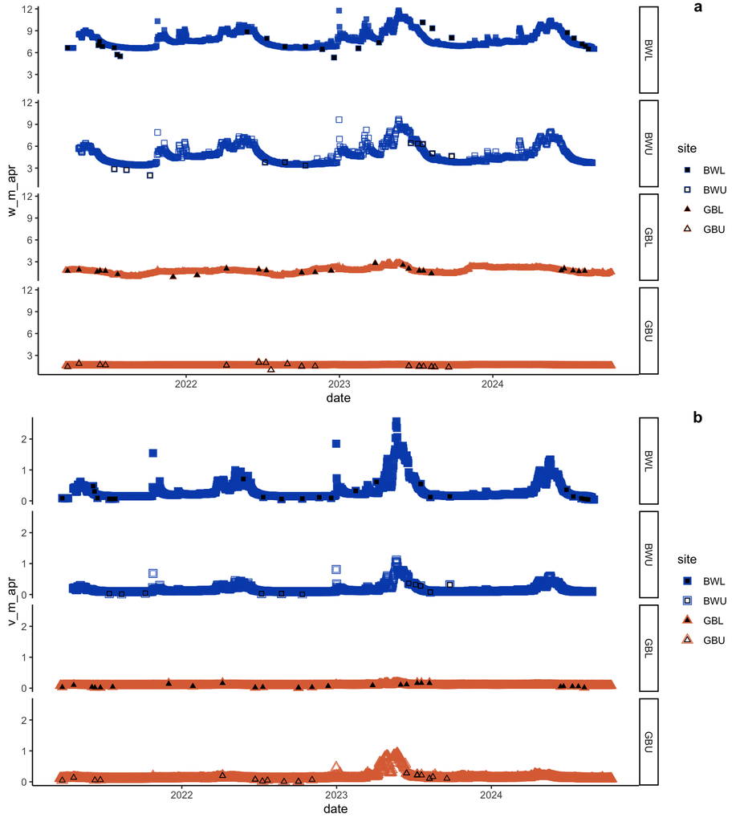

#### Calculate nitrogen supply:

```r
covariat_nsupply <- covariat_datqI %>%
  dplyr::select(site, catch, date, water_year,
                reach_length,
                v_m_apr,w_m_apr, Q_m, K600_daily_mean,
                NO3_mgL_dl_sw, NH4_mgL_dl_sw, PO4_ugL_dl_sw)%>%
  # group_by(site) %>%
  # arrange(date) %>%  # Ensure chronological order
  # # mutate( ## 17 NAs
  #   v_mi = ifelse(is.na(v_m),
  #                 rollapplyr(v_m, width = 3, FUN = function(x) mean(x, na.rm = TRUE), fill = NA, partial = TRUE),
  #                 v_m),
  #   w_mi = ifelse(is.na(w_m),
  #                 rollapplyr(w_m, width = 3, FUN = function(x) mean(x, na.rm = TRUE), fill = NA, partial = TRUE),
  #                 w_m)
  # ) %>%
  # # Carry forward any remaining NAs
  # # mutate(
  #   v_mi = zoo::na.locf(v_mi, na.rm = FALSE),
  #   v_mi = zoo::na.locf(v_mi, fromLast = TRUE, na.rm = FALSE),
  #   w_mi = zoo::na.locf(w_mi, na.rm = FALSE),
  #   w_mi = zoo::na.locf(w_mi, fromLast = TRUE, na.rm = FALSE)
  # ) %>%
  # # If there are still missing values, replace them with the site mean
  # mutate(
  #   v_mi = ifelse(is.na(v_mi), mean(v_m, na.rm = TRUE), v_mi),
  #   w_mi = ifelse(is.na(w_mi), mean(w_m, na.rm = TRUE), w_mi)
  # ) %>%
  # # mean measured estimates o k600
  mutate(
    K600_daily_mean = case_when(
      is.na(K600_daily_mean) & site == "BWL" ~ 22,
      is.na(K600_daily_mean) & site == "BWU" ~ 16,
      is.na(K600_daily_mean) & site == "GBU" ~ 32,
      is.na(K600_daily_mean) & site == "GBL" ~ 25,
      TRUE ~ K600_daily_mean
    )
  ) %>%
  mutate(
  Q_Ls = Q_m * 1000, # flow from csm to Ls
  # calculate reach length in m
   reachL = c((v_m_apr*w_m_apr*8640)/K600_daily_mean), # seconds to days
   # Calculate no3 supply
  NO3_supply = c(((86400*Q_Ls*(NO3_mgL_dl_sw/1000))/(w_m_apr*reachL))),
   # Calculate nh3 supply
  NH4_supply = c(((86400*Q_Ls*(NH4_mgL_dl_sw/1000))/(w_m_apr*reachL))), ## unit should be g N m-2 d-1
  PO4_supply = c(((86400*Q_Ls*(PO4_ugL_dl_sw/1e-6))/(w_m_apr*reachL))) ## unit should be g N m-2 d-1
   )  %>%
  dplyr::select(site, date, reachL, reach_length, Q_Ls, NO3_supply, NH4_supply, PO4_supply)
```

#### As a follow up… Which type of reach length works best?

Covino et al picked a static length -

“…Our experimental stream reach was near the Wooden Bridge in the Korstian Division and stretched 175 and 200 m up- and downstream, respectively.. We used a stream length of 100 m (King et al. 2014). Ideal estimates of supply to the stream bed would exceed the stream length over which the water column mixes vertically and, therefore, solutes would be available to the bed, but we lacked hydrodynamic information to estimate this length…”

Here I chose to estimate instead estimate reach length based off Laurel’s advice for using the gas exchange estimates to get estimate theoretic reach length. Where reach length = velocity (m s^-1) * width (in m) / gas exchange (m day^-1). But the empirical RL is calculated across the entire non- trimmed time sieries of flow so does have some outlines at peak flows. Often when we weren’t sampling and also where we didn’t model metabolism).

```
##    Min. 1st Qu.  Median    Mean 3rd Qu.    Max.    NA's
##    50.0    75.0   100.0   101.1   100.0   250.0    5196
```

```
##      Min.   1st Qu.    Median      Mean   3rd Qu.      Max.      NA's
##     2.948    53.026   175.565   512.766   487.630 12414.389       134
```

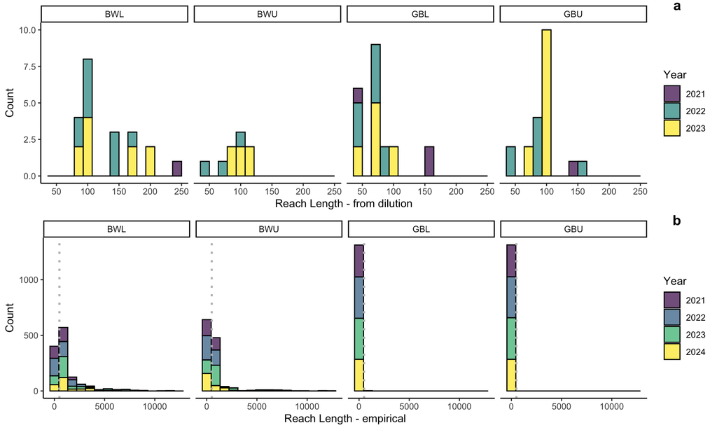

The vertical dotted line is 500 m to help compare ranges with the large range of unrealistic RL at high flows.

Here’s the empirical RL trimmed to just show distribution under of RL under 1000

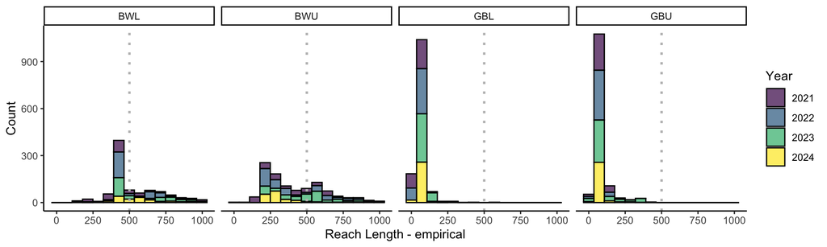

##### Plots of Ratios of NH4+- N supply to demand, ratios NO3– N supply to demand

Old figure 4 with gas exchange filled in based on measurements and no longer an NA when metabolism model failed to estimate that parameter on the same day as the chemistry sample… to have way more data:

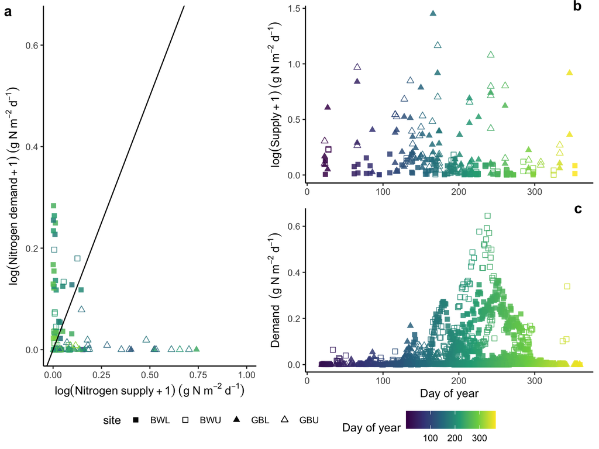

### Nitrogen Uptake dynamics from TASCC

```r
n_df <- n_up%>%
  filter(success=="yes") %>%
  mutate(
         Uadd_g_m2_min = c(Uadd_ug_L_min/1000000),
         Uadd_g_m2_D = c(Uadd_g_m2_min*1440))

uptake <- n_df %>%
  pivot_wider(
    names_from = method,
    values_from = Uadd_g_m2_D,
    names_prefix = "Uadd_g_m2_D_") %>%
  dplyr::select(site, date, Uadd_g_m2_D_NH3, Uadd_g_m2_D_NO3)

summary(uptake)
```

```
##      site                date            Uadd_g_m2_D_NH3    Uadd_g_m2_D_NO3
##  Length:53          Min.   :2022-04-07   Min.   :0.003370   Min.   :0.001037
##  Class :character   1st Qu.:2022-10-03   1st Qu.:0.009677   1st Qu.:0.004990
##  Mode  :character   Median :2023-03-27   Median :0.020218   Median :0.010238
##                     Mean   :2023-02-16   Mean   :0.031153   Mean   :0.014882
##                     3rd Qu.:2023-07-18   3rd Qu.:0.036850   3rd Qu.:0.020261
##                     Max.   :2023-09-25   Max.   :0.174442   Max.   :0.069293
##                                          NA's   :26         NA's   :27
```

```r
uptake_df <-  covariat_NS_ND%>%
  full_join(uptake)
```

### Linking ecosystem funtion and biogeochemical dynamics:

We found that autotrophic production (and so nitrogen demand) is suppressed in wetter years and this matters because the NH4 supply increases also increases in wetter years.

- We would like to estimate what amount of the nitrogen supply can be could be transformed via uptake in a stream - possibly at specific stream reach?
  - Fractional uptake efficiencies for N at the lower station as downstream export?
  - Difference in fractional uptake efficiencies between reaches for overall stream processing?
- Even though supply increases, we would expect biological processes like uptake to decrease. So what percent of the N supply is either processes or exported in wet verse dry years?

##### Consider the units

- Areal max uptake - Ut - ug / m2 min -> we converted to g m2 day
- Uptake velocity - Vf - m / min
- Uptake length - Sw - m
- Supply and demand is in g N m-2 d-1

### New analysis of Nitrogen dynamics:

#### Methods for evaluating nitrogen cycling

According to Covino et al. 2018 :

- Supply (S): The available nitrogen in the system (in g N/m²/day).
- Demand (D): The total biological nitrogen demand (in g N/m²/day).
- Uptake rate (U): The amount of nitrogen removed from the water column via assimilation, denitrification, or other biological processes.

#### U = (D * S) / (D + S)

- When demand (D) is much greater than supply (S): Almost all available nitrogen is taken up, so uptake approaches supply (U ≈ S)
- When supply (S) is much greater than demand (D): Uptake is limited by biological demand, and uptake approaches demand (U ≈ D)

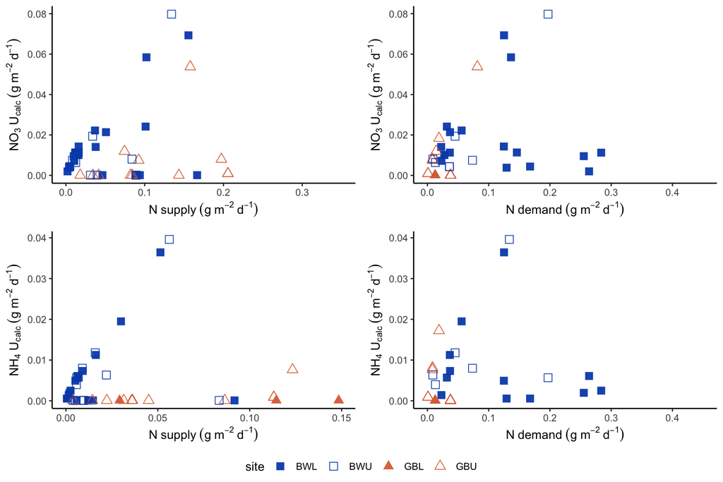

Uptake is approaching demand (U ≈ D) indicating in general supply is greater than demand at each reach for N and something other than supply is limiting biologic uptake.

“high_Ndemand_threshold <- 0.037”

```
## # A tibble: 4 × 6
##   site  count mean_Ndemand max_Ndemand earliest_date latest_date
##   <chr> <int>        <dbl>       <dbl> <date>        <date>
## 1 BWL     259       0.166       0.365  2021-05-20    2024-08-15
## 2 BWU     151       0.181       0.645  2021-07-01    2023-10-24
## 3 GBU      22       0.0551      0.0846 2021-06-03    2022-09-24
## 4 GBL      11       0.0700      0.168  2021-05-14    2024-03-26
```

#### Identify High NO3 supply Events 2021-2023

“high_NO3_sup_threshold <- 0.039”

```
## # A tibble: 4 × 6
##   site  count mean_NO3_supply max_NO3_supply earliest_date latest_date
##   <chr> <int>           <dbl>          <dbl> <date>        <date>
## 1 GBL      40           0.574          3.27  2021-05-05    2023-10-19
## 2 GBU      28           0.600          2.20  2021-05-18    2023-10-19
## 3 BWL      24           0.115          0.207 2021-05-05    2023-09-20
## 4 BWU      12           0.108          0.252 2022-07-09    2023-09-20
```

#### Identify High NH4 supply Events 2021-2023

“high_NO3_sup_threshold <- 0.018”

```
## # A tibble: 4 × 6
##   site  count mean_NH4_supply max_NH4_supply earliest_date latest_date
##   <chr> <int>           <dbl>          <dbl> <date>        <date>
## 1 GBL      38          0.285          1.50   2021-06-23    2023-10-19
## 2 GBU      29          0.311          1.22   2021-06-23    2023-10-19
## 3 BWL      12          0.0512         0.0917 2021-07-14    2023-08-23
## 4 BWU      10          0.106          0.263  2021-07-14    2023-10-25
```

#### Plot high events 2021-2023

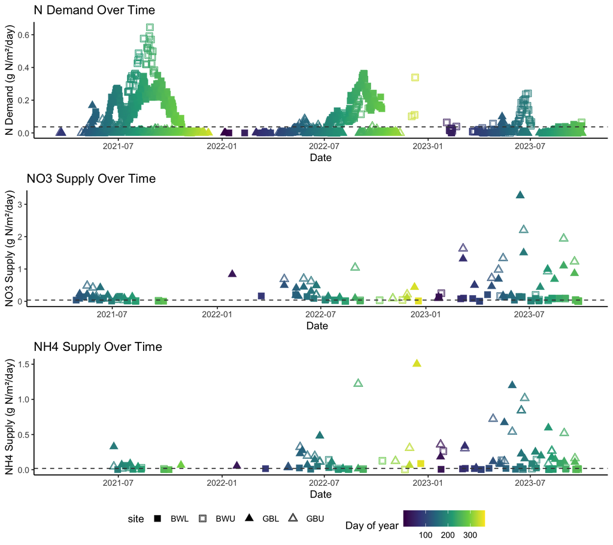

#### Fractional uptake efficiency for each nitrogen type:

A value close to 1 suggests high efficiency, meaning most of the supplied nitrogen was absorbed, while a value close to 0 suggests that most of the supplied nitrogen remained in the system

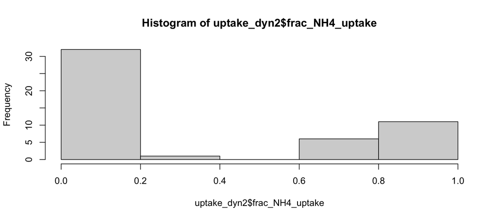

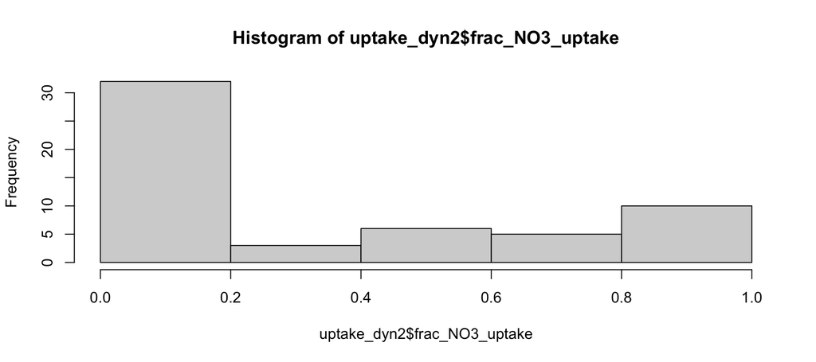

#### Time sieries of fractional uptake efficiency in for each N:

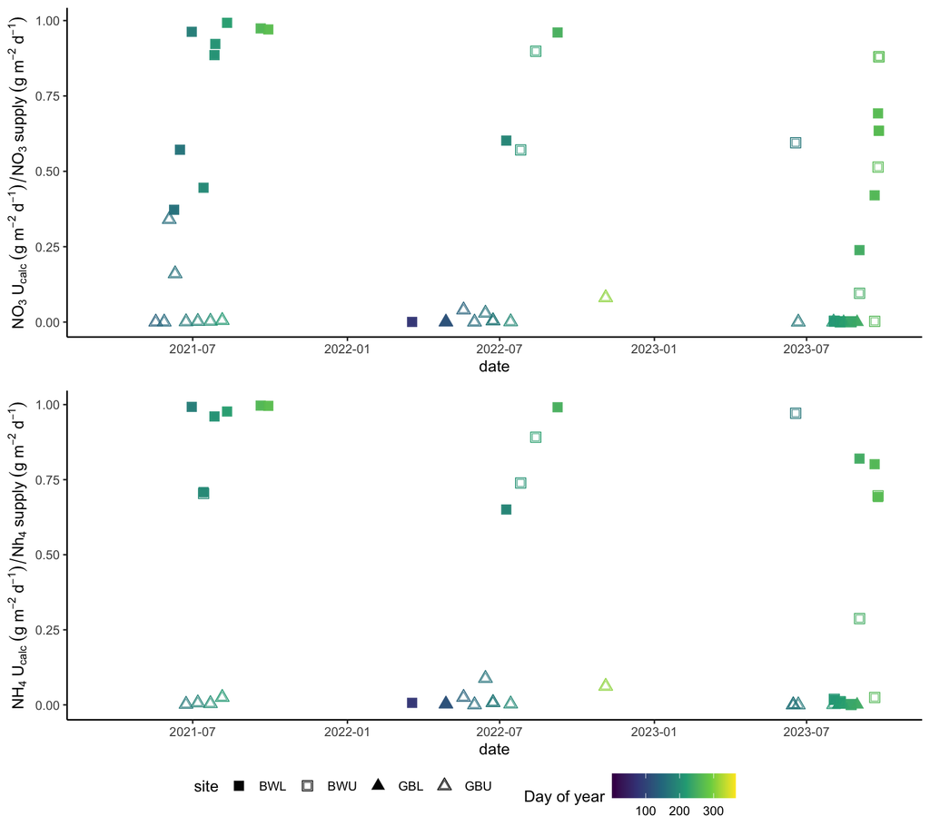

#### Summary of fractional uptake of N from dry to wet years

```
## # A tibble: 8 × 5
## # Groups:   site [4]
##   site  WY_lab frac_NO3_uptake frac_NH4_uptake frac_N_uptake
##   <chr> <chr>            <dbl>           <dbl>         <dbl>
## 1 BWL   dry           0.722           0.809          0.851
## 2 BWL   wet           0.292           0.335          0.398
## 3 BWU   dry           0.735           0.778          0.911
## 4 BWU   wet           0.297           0.253          0.308
## 5 GBL   dry           0.000201        0.00341        0.00681
## 6 GBL   wet           0.000119        0.000671       0.00155
## 7 GBU   dry           0.0396          0.0159         0.0306
## 8 GBU   wet           0.0271          0.0127         0.0394
```

### Nitrogen dynamics within streams from upper to lower reaches:

#### Looking at possible nitrogen retention with BW or GB:

- NO₃/NH₄ retention fraction close to 1: Most nitrogen is processed/retained before reaching the lower reach.
- NO₃/NH₄ retention fraction close to 0: Most nitrogen passes downstream unchanged.
- Negative retention values: suggest an increase in nitrogen downstream, possibly from inputs like tributaries or groundwater

```r
# Define reach lengths
bw_reach_length <- 4150  # meters (BWU to BWL)
gb_reach_length <- 1100  # meters (GBU to GBL)

# Calculate NO3 and NH4 retention with reach area
reach_rent <- uptake_dyn %>%
  filter(site %in% c("BWU", "BWL", "GBU", "GBL")) %>%
  group_by(catch, date) %>%
  summarize(
    NO3_supply_upper = NO3_supply[site %in% c("BWU", "GBU")],
    NO3_supply_lower = NO3_supply[site %in% c("BWL", "GBL")],
    NH4_supply_upper = NH4_supply[site %in% c("BWU", "GBU")],
    NH4_supply_lower = NH4_supply[site %in% c("BWL", "GBL")],
    U_NO3_upper = U_NO3_calc[site %in% c("BWU", "GBU")],
    U_NO3_lower = U_NO3_calc[site %in% c("BWL", "GBL")],
    U_NH4_upper = U_NH4_calc[site %in% c("BWU", "GBU")],
    U_NH4_lower = U_NH4_calc[site %in% c("BWL", "GBL")],
    w_m_upper = w_m[site %in% c("BWU", "GBU")],  # Stream width for upper reach
    w_m_lower = w_m[site %in% c("BWL", "GBL")]   # Stream width for lower reach
  ) %>%
  mutate(
    # Assign reach length based on the system
    reach_length = case_when(
      catch == "BW" ~ bw_reach_length,
      catch == "GB" ~ gb_reach_length
    ),
    # Calculate reach area (reach length * width)
    reach_area = reach_length * ((w_m_upper + w_m_lower) / 2),  # Average width

    # Calculate NO3 and NH4 retention fractions
    NO3_retention = 1 - (NO3_supply_lower / NO3_supply_upper),
    NH4_retention = 1 - (NH4_supply_lower / NH4_supply_upper),

    # Calculate processed nitrogen (g/m2/day × reach area)
    NO3_processed = (NO3_supply_upper - NO3_supply_lower) * reach_area,
    NH4_processed = (NH4_supply_upper - NH4_supply_lower) * reach_area
  )%>%
  mutate(jday=yday(date))
summary(reach_rent)
```

```
##     catch                date            NO3_supply_upper NO3_supply_lower
##  Length:2619        Min.   :2021-03-20   Min.   :0.0049   Min.   :0.0020
##  Class :character   1st Qu.:2022-02-10   1st Qu.:0.0347   1st Qu.:0.0377
##  Mode  :character   Median :2022-12-30   Median :0.0894   Median :0.1153
##                     Mean   :2022-12-30   Mean   :0.3251   Mean   :0.2967
##                     3rd Qu.:2023-11-18   3rd Qu.:0.2522   3rd Qu.:0.3380
##                     Max.   :2024-10-10   Max.   :2.2033   Max.   :3.2674
##                                          NA's   :2562     NA's   :2531
##  NH4_supply_upper NH4_supply_lower  U_NO3_upper      U_NO3_lower
##  Min.   :0.0023   Min.   :0.0006   Min.   :0.0001   Min.   :0.0001
##  1st Qu.:0.0147   1st Qu.:0.0122   1st Qu.:0.0001   1st Qu.:0.0001
##  Median :0.0849   Median :0.0514   Median :0.0001   Median :0.0095
##  Mean   :0.1843   Mean   :0.1515   Mean   :0.0075   Mean   :0.0122
##  3rd Qu.:0.2140   3rd Qu.:0.1564   3rd Qu.:0.0075   3rd Qu.:0.0141
##  Max.   :1.2206   Max.   :1.5027   Max.   :0.0798   Max.   :0.0693
##  NA's   :2563     NA's   :2542     NA's   :2588     NA's   :2594
##   U_NH4_upper      U_NH4_lower       w_m_upper       w_m_lower
##  Min.   :0.0001   Min.   :0.0001   Min.   :1.010   Min.   : 0.910
##  1st Qu.:0.0001   1st Qu.:0.0001   1st Qu.:1.510   1st Qu.: 1.760
##  Median :0.0001   Median :0.0006   Median :1.870   Median : 2.800
##  Mean   :0.0040   Mean   :0.0045   Mean   :2.745   Mean   : 4.509
##  3rd Qu.:0.0058   3rd Qu.:0.0055   3rd Qu.:3.790   3rd Qu.: 6.860
##  Max.   :0.0396   Max.   :0.0364   Max.   :6.450   Max.   :10.140
##  NA's   :2591     NA's   :2597     NA's   :2580    NA's   :2554
##   reach_length    reach_area    NO3_retention     NH4_retention
##  Min.   :1100   Min.   : 1568   Min.   :-6.9096   Min.   :-9.1974
##  1st Qu.:1100   1st Qu.: 1798   1st Qu.:-0.6891   1st Qu.:-1.8494
##  Median :4150   Median : 2024   Median : 0.0949   Median : 0.1929
##  Mean   :2626   Mean   :11022   Mean   :-0.3213   Mean   :-0.9649
##  3rd Qu.:4150   3rd Qu.:21995   3rd Qu.: 0.4909   3rd Qu.: 0.7318
##  Max.   :4150   Max.   :34051   Max.   : 0.9055   Max.   : 0.9894
##                 NA's   :2590    NA's   :2569      NA's   :2570
##  NO3_processed      NH4_processed          jday
##  Min.   :-666.505   Min.   :-795.79   Min.   :  1.0
##  1st Qu.:-530.679   1st Qu.:-410.50   1st Qu.:101.0
##  Median :-247.990   Median : -74.46   Median :183.0
##  Mean   :  -3.219   Mean   : -15.35   Mean   :182.9
##  3rd Qu.:  -2.797   3rd Qu.: 144.64   3rd Qu.:264.0
##  Max.   :1323.468   Max.   :1220.65   Max.   :365.0
##  NA's   :2609       NA's   :2607
```

```r
reach_rent<- water_year(reach_rent)
```

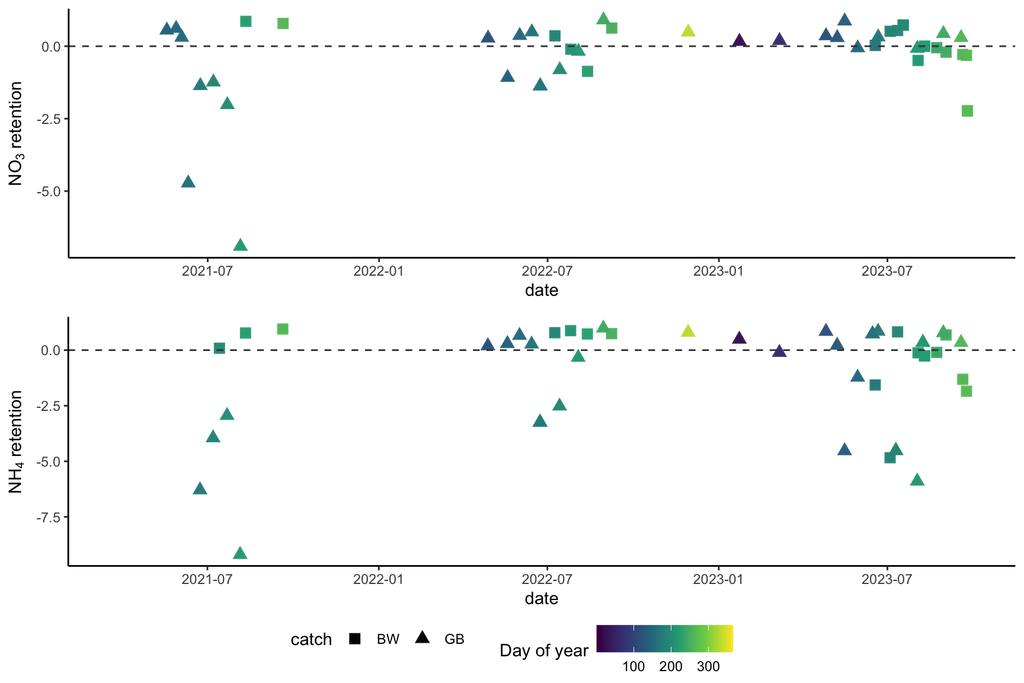

#### summerize stream N uptake of N from dry to wet years

```
## # A tibble: 4 × 4
## # Groups:   catch [2]
##   catch WY_lab NO3_retention NH4_retention
##   <chr> <chr>          <dbl>         <dbl>
## 1 BW    dry            0.276         0.706
## 2 BW    wet           -0.233        -0.880
## 3 GB    dry           -1.03         -2.26
## 4 GB    wet            0.298        -0.843
```

## Final thoughts:

### Synthesizing conclusions:

In general uptake rates remained low even at high supply values. And implies in most instances that nitrogen supply is not the limiting factor in nitrogen cycling rates, even though there appears to be nitrogen limitation based on the N:P ratios of nitrogen availability. Instead, biological demand, uptake efficiency, or environmental conditions (e.g., temperature and flow conditions) could be controlling nitrogen processing rates.